# Removing image backgrounds with magick

magick

tables

Tables with dark backgrounds deserve transparent logos!

Thomas Mock https://twitter.com/thomas_mock  
01-28-2021

## The Problem

Colin Welsh reached out on [Twitter](https://twitter.com/fakeColinW/status/1353860010758049793?s=20) asking about removing the background from player headshots for use in dark-themed table. He had a bunch of player headshots for the NHL, but they had a white background which he wanted to remove and then embed the headshots in `gt`.

He thought that `{magick}` could be used to remove the background, and let’s see what we can do!

If you missed my last [blogpost](https://themockup.blog/posts/2021-01-18-reading-tables-from-images-with-magick/), it has some more details on the [`{magick}`](https://docs.ropensci.org/magick/index.html) package. In short, `{magick}` is an R wrapper around the ImageMagick library that is used for image processing.

For another fantastic longer form blogpost, make sure to check out Deemah’s blogpost on [Miracles with magick](https://www.ddrive.no/post/miracles-with-magick-and-bunny/)! I adapted some of his examples for the logos at the end. He pointed out rightfully so, that simply replacing ALL white with transparent can have some negative effects (this REALLy is a problem with logos). I’ve gone ahead and rebuilt the examples with that in mind.

## Load the Data

We’ll load our libraries and pull in the data of interest, there are a lot of columns but I’ll limit it to a subset later on.

```
library(tidyverse)
library(gt)
library(magick)

skater_game_score <- read_rds(url('https://github.com/Colinifer/hockey/blob/master/gt_help_dataset.rds?raw=true'))

glimpse(skater_game_score)
```

```
Rows: 50
Columns: 26
$ player          <chr> "CONNOR.MCDAVID", "NATHAN.MACKINNON", "MIKK…
$ games           <int> 7, 6, 6, 6, 6, 7, 6, 6, 7, 7, 6, 6, 6, 6, 6…
$ g               <dbl> 4, 2, 5, 1, 5, 4, 3, 3, 4, 3, 0, 1, 3, 2, 4…
$ a1              <dbl> 4, 5, 1, 6, 1, 6, 1, 1, 2, 4, 2, 4, 2, 4, 1…
$ a2              <dbl> 2, 1, 1, 3, 2, 0, 2, 3, 1, 2, 5, 1, 4, 2, 2…
$ pts             <dbl> 10, 8, 7, 10, 8, 10, 6, 7, 7, 9, 7, 6, 9, 8…
$ gs_tot          <dbl> 11.855, 10.630, 10.020, 9.785, 9.690, 9.135…
$ team.x          <chr> "EDM", "COL", "COL", "L.A", "MTL", "TOR", "…
$ gs_avg          <dbl> 1.5067857, 1.7733333, 1.8225000, 1.7329167,…
$ num_last_first  <chr> "97 MCDAVID, CONNOR", "29 MACKINNON, NATHAN…
$ player_team_num <chr> "EDM97", "COL29", "COL96", "L.A11", "MTL73"…
$ position        <chr> "C", "C", "R", "C", "C", "C", "C", "C", "C"…
$ position_type   <chr> "F", "F", "F", "F", "F", "F", "F", "F", "F"…
$ season          <chr> "20202021", "20202021", "20202021", "202020…
$ session         <chr> "R", "R", "R", "R", "R", "R", "R", "R", "R"…
$ team.y          <chr> "EDM", "COL", "COL", "L.A", "MTL", "TOR", "…
$ jersey_number   <dbl> 97, 29, 96, 11, 73, 16, 34, 87, 91, 29, 9, …
$ first_name      <chr> "CONNOR", "NATHAN", "MIKKO", "ANZE", "TYLER…
$ last_name       <chr> "MCDAVID", "MACKINNON", "RANTANEN", "KOPITA…
$ year            <int> 20202021, 20202021, 20202021, 20202021, 202…
$ full_name       <glue> "CONNOR MCDAVID", "NATHAN MACKINNON", "MIK…
$ team_name       <chr> "Oilers", "Avalanche", "Avalanche", "Kings"…
$ player_id       <int> 8478402, 8477492, 8478420, 8471685, 8475726…
$ logo            <chr> "http://content.sportslogos.net/logos/1/12/…
$ headshot_url    <glue> "https://cms.nhl.bamgrid.com/images/headsh…
$ action_shot_url <glue> "https://cms.nhl.bamgrid.com/images/action…
```

## Initial Table

We can quickly convert this into `gt` table like so. Look pretty good, and the player headshots look fine as well.

```
skater_game_score %>%
  slice(1:10) %>%
  select(player, headshot_url, games:pts)%>%
  gt() %>%
  text_transform(
    locations = cells_body(vars(headshot_url)),
    fn = function(x){
      web_image(url = x)
    }
  )
```

| player | headshot_url | games | g | a1 | a2 | pts |
| --- | --- | --- | --- | --- | --- | --- |
| CONNOR.MCDAVID |  | 7 | 4 | 4 | 2 | 10 |
| NATHAN.MACKINNON |  | 6 | 2 | 5 | 1 | 8 |
| MIKKO.RANTANEN |  | 6 | 5 | 1 | 1 | 7 |
| ANZE.KOPITAR |  | 6 | 1 | 6 | 3 | 10 |
| TYLER.TOFFOLI |  | 6 | 5 | 1 | 2 | 8 |
| MITCH.MARNER |  | 7 | 4 | 6 | 0 | 10 |
| AUSTON.MATTHEWS |  | 6 | 3 | 1 | 2 | 6 |
| SIDNEY.CROSBY |  | 6 | 3 | 1 | 3 | 7 |
| JOHN.TAVARES |  | 7 | 4 | 2 | 1 | 7 |
| LEON.DRAISAITL |  | 7 | 3 | 4 | 2 | 9 |

The *real* problem here is that Colin was interested in using a black background for his table. Let’s see what that looks like. Here we can see that the player background adds a lot of unnecessary white to our otherwise nice looking black table.

```
skater_game_score %>%
  slice(1:10) %>%
  select(player, headshot_url, games:pts)%>%
  gt() %>%
  text_transform(
    locations = cells_body(vars(headshot_url)),
    fn = function(x){
      web_image(url = x)
    }
  ) %>%
  tab_options(
    table.background.color = "black"
  )
```

| player | headshot_url | games | g | a1 | a2 | pts |
| --- | --- | --- | --- | --- | --- | --- |
| CONNOR.MCDAVID |  | 7 | 4 | 4 | 2 | 10 |
| NATHAN.MACKINNON |  | 6 | 2 | 5 | 1 | 8 |
| MIKKO.RANTANEN |  | 6 | 5 | 1 | 1 | 7 |
| ANZE.KOPITAR |  | 6 | 1 | 6 | 3 | 10 |
| TYLER.TOFFOLI |  | 6 | 5 | 1 | 2 | 8 |
| MITCH.MARNER |  | 7 | 4 | 6 | 0 | 10 |
| AUSTON.MATTHEWS |  | 6 | 3 | 1 | 2 | 6 |
| SIDNEY.CROSBY |  | 6 | 3 | 1 | 3 | 7 |
| JOHN.TAVARES |  | 7 | 4 | 2 | 1 | 7 |
| LEON.DRAISAITL |  | 7 | 3 | 4 | 2 | 9 |

## Clean the images

So our goal is to remove the white background and turn it transparent. There are 3 steps here:

- Extract the image name
- Optionally trim extra whitespace from the images
- Turn the background white into transparent and save to disk

### Extract the image name

We have a url that points at a player headshot. An example is:

`https://cms.nhl.bamgrid.com/images/headshots/current/168x168/8478402.jpg`

Which returns:

[figure not shown]

Now, we only need the image name, not the URL. We can remove the extra “fluff” around the image name with `regex` + `stringr::str_replace()` or `base::gsub()`.

Now… if you’re anything like me, the below `regex` kind of looks like gibberish.

```
ex_url <- "https://cms.nhl.bamgrid.com/images/headshots/current/168x168/8478402.jpg"

str_replace(ex_url, ".*[/]([^.]+)[.].*", "\\1")
```

```
[1] "8478402"
```

If you want to see some explanations for the `regex`, see the details tag below.

**Fun aside on `regex`**

This `regex` code: `.*[/]([^.]+)[.].*` gives us the following explanation at [regex101.com](https://regex101.com/)

- `.*` matches any character (except for line terminators)
  - `*` Quantifier — Matches between zero and unlimited times, as many times as possible, giving back as needed (greedy)
  - This basically finds everything up to the next portion
- Match a single character present in the list below `[/]`
  - `/` matches the character `/` literally (case sensitive)
  - This finds a literal `/` and with the previous code (`.*`) all the stuff before it
- 1st Capturing Group `([^.]+)`
  - Match a single character not present in the list below `[^.]+`
    - `+` Quantifier — Matches between one and unlimited times, as many times as possible, giving back as needed (greedy)
    - `.` matches the character `.` literally (case sensitive)
  - A capture group allows us to reference this portion later (with `\\1`)
- Match a single character present in the list below `[.]`
  - `.` matches the character . literally (case sensitive)
  - Find the `.` and then anything after the `.`
- `.*` matches any character (except for line terminators)
  - `*` Quantifier — Matches between zero and unlimited times, as many times as possible, giving back as needed (greedy)

We can see the capture group via `str_match()`, this will separate out the full match from the capture group.

```
str_match(ex_url, ".*[/]([^.]+)[.].*")
```

```
     [,1]
[1,] "https://cms.nhl.bamgrid.com/images/headshots/current/168x168/8478402.jpg"
     [,2]
[1,] "8478402"
```

Note that this could actually be much simpler to fix…just remove the static portions!

```
ex_url %>%
  str_remove("https://cms.nhl.bamgrid.com/images/headshots/current/168x168/") %>%
  str_remove(".jpg")
```

```
[1] "8478402"
```

### Trim the image and remove background

- `fuzz`: relative color distance (value between 0 and 100) to be considered similar in the filling algorithm
- `refcolor = "white"`: the reference color that we’re replacing
- `color = "transparent"`: the replacement of white with transparent
- `point = "+1+1"`: The location where we start “filling” or flooding the image with replacement, where `'1+1'` indicates 1 pixel in from the top left

```
# clean image and write to disk
clean_img_transparent <- function(img_url, trim = FALSE){

  # find the name of the img and extract it
  img_name <- str_replace(img_url, ".*[/]([^.]+)[.].*", "\\1")

  # some images need to be trimmed
  trim_area <- if(isTRUE(trim)){
    geometry_area(0, 0, 0, 10)
  } else {
    geometry_area(0, 0, 0, 0)
  }

  img_url %>%
    image_read() %>%
    image_crop(geometry = trim_area) %>%
    image_fill(
      color = "transparent",
      refcolor = "white",
      fuzz = 4,
      point = "+1+1" # start at top left 1 pixel in
      )
}
```

We can test the function with and without trimming, then stack them next to each other. I will use `image_ggplot()` to “show” the image in this RMarkdown blog, but interactively you could remove that as it prints to the R Console.

```
img_ex <- clean_img_transparent(ex_url)
img_ex_trim <- clean_img_transparent(ex_url, trim = TRUE)

c(img_ex, img_ex_trim) %>%
  image_append() %>%
  image_ggplot()
```

[figure not shown]

This looks great, but the for the last portion we’ll need to write to disk. It doesn’t really “look” any different, but the whitepspace around the player image is now “transparent”.

We could see this more clearly by replacing with a different color. Note that again if you just used `image_transparent()` as I did in a previous version of this post you’d “lose” some white details in the player’s jersey/sweater.

```
ex_url %>%
    image_read() %>%
    image_crop(geometry = geometry_area(0, 0, 0, 10)) %>%
    image_fill(
      color = "green",
      refcolor = "white",
      fuzz = 4,
      point = "+1+1" # start at top left 1 pixel in
      ) %>%
  image_ggplot()
```

[figure not shown]

### Write to disk

We can now use `image_write()` to write the image to disk so it can be used with `gt::local_image()`. We’ll add that to our function.

```
# clean image and write to disk
clean_img_transparent <- function(img_url, trim = FALSE){

  # find the name of the img and extract it
  img_name <- str_replace(img_url, ".*[/]([^.]+)[.].*", "\\1")

  # some images need to be trimmed
  trim_area <- if(isTRUE(trim)){
    geometry_area(0, 0, 0, 10)
  } else {
    geometry_area(0, 0, 0, 0)
  }

  img_url %>%
    image_read() %>%
    image_crop(geometry = trim_area) %>%
    image_fill(
      color = "transparent",
      refcolor = "white",
      fuzz = 4,
      point = "+1+1"
      ) %>%
    image_write(path = paste0(img_name, ".png"), format = "png")
}
```

# All together now

Now we need to get the top 10 players, grab the `headshot_url` column, and then remove any missing images (`na.jpg`), trim the first image, and then write out to disk.

```
skater_game_score <- read_rds(url('https://github.com/Colinifer/hockey/blob/master/gt_help_dataset.rds?raw=true'))

skater_include <- skater_game_score %>%
  slice(1:10) %>%
  select(img_url = headshot_url) %>%
  filter(str_detect(img_url, pattern = "NA.jpg", negate = TRUE)) %>%
  mutate(trim = c(TRUE, rep(FALSE, 9)))

skater_include
```

```
# A tibble: 10 x 2
   img_url                                                       trim
   <glue>                                                        <lgl>
 1 https://cms.nhl.bamgrid.com/images/headshots/current/168x168… TRUE
 2 https://cms.nhl.bamgrid.com/images/headshots/current/168x168… FALSE
 3 https://cms.nhl.bamgrid.com/images/headshots/current/168x168… FALSE
 4 https://cms.nhl.bamgrid.com/images/headshots/current/168x168… FALSE
 5 https://cms.nhl.bamgrid.com/images/headshots/current/168x168… FALSE
 6 https://cms.nhl.bamgrid.com/images/headshots/current/168x168… FALSE
 7 https://cms.nhl.bamgrid.com/images/headshots/current/168x168… FALSE
 8 https://cms.nhl.bamgrid.com/images/headshots/current/168x168… FALSE
 9 https://cms.nhl.bamgrid.com/images/headshots/current/168x168… FALSE
10 https://cms.nhl.bamgrid.com/images/headshots/current/168x168… FALSE
```

I’ll use `pwalk()` to pass the urls + trim argument to `clean_img_transparent()` for each of the combos.

```
skater_include%>%
  pwalk(clean_img_transparent)
```

We can then read them back in and apply to a `gt` table, and boom we’re done!

```
skater_game_score %>%
  slice(1:10) %>%
  mutate(
    img_name = str_replace(headshot_url, ".*[/]([^.]+)[.].*", "\\1"),
    img_name = paste0(img_name, ".png"),
    img_name = map(img_name, local_image),
    img_name = map(img_name, ~html(as.character(.x)))
    ) %>%
  select(player, img_name, games:pts) %>%
  gt() %>%
  tab_options(
    table.background.color = "black"
  )
```

player

img_name

games

g

a1

a2

pts

CONNOR.MCDAVID

[figure not shown]

7

4

4

2

10

NATHAN.MACKINNON

[figure not shown]

6

2

5

1

8

MIKKO.RANTANEN

[figure not shown]

6

5

1

1

7

ANZE.KOPITAR

[figure not shown]

6

1

6

3

10

TYLER.TOFFOLI

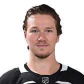

6

5

1

2

8

MITCH.MARNER

[figure not shown]

7

4

6

0

10

AUSTON.MATTHEWS

[figure not shown]

6

3

1

2

6

SIDNEY.CROSBY

[figure not shown]

6

3

1

3

7

JOHN.TAVARES

[figure not shown]

7

4

2

1

7

LEON.DRAISAITL

[figure not shown]

7

3

4

2

9

# What about the logos?

Now, the logos present another problem, they have large whitespace areas INSIDE the logos themselves… so if you were to apply a global transparency they would end up transparent INSIDE the logos where they should be white.

Again, for another fantastic longer form blogpost, make sure to check out Deemah’s blogpost on [Miracles with magick](https://www.ddrive.no/post/miracles-with-magick-and-bunny/)! I looked through some of his examples, although I used a slightly different workflow here for the logos. Another `ImageMagick` proper blogpost from [Nate Murray](http://tech.natemurray.com/2007/12/convert-white-to-transparent.html) was also very useful.

So here, we’ll need to convert some of our code, but it will still turn out pretty good! Again please note, that I’m using `image_ggplot()` just to show it in the blogpost, and interactively you can just return the output to the RStudio viewer.

## Logo Fill

We can use a logo with a lot of whitespace, to play around with.

```
logo_url  <- "http://content.sportslogos.net/logos/1/16/thumbs/124.gif"

raw_logo <- logo_url %>%
  image_read()

raw_logo %>%
  image_ggplot()
```

[figure not shown]

For our steps we’re going to fill (basically flood) in the white space around the logo with green. Now because some logos (like the Avalanche) have areas that can’t get flooded with color in one path, I’m going to flood at each corner (top left, top right, bottom left, bottom right). For our real usage, we’re going to convert this “green” space to transparent instead.

```
img_filled <- raw_logo %>%
    image_fill("green", "+1+1", fuzz = 50, refcolor = "white") %>%
    image_fill("green", "+140+1", fuzz = 50, refcolor = "white") %>%
    image_fill("green", "+1+99", fuzz = 50, refcolor = "white") %>%
    image_fill("green", "+140+99", fuzz = 50, refcolor = "white")

img_filled %>%
  image_ggplot()
```

[figure not shown]

```
img_filled <- raw_logo %>%
    image_fill("transparent", "+1+1", fuzz = 50, refcolor = "white") %>%
    image_fill("transparent", "+140+1", fuzz = 50, refcolor = "white") %>%
    image_fill("transparent", "+1+99", fuzz = 50, refcolor = "white") %>%
    image_fill("transparent", "+140+99", fuzz = 50, refcolor = "white")
```

## Logo edges and mask

Now that we have a transparency around the logo, we can take that ‘opacity’ channel and extract everything but that.

```
img_filled %>%
    image_channel("Opacity") %>%
    image_convert(matte=FALSE) %>%
  image_ggplot()
```

[figure not shown]

Now to create a proper “mask” that we can apply to the image, we can negate this and apply a gentle blur to make the edges not as “sharp” against the background.

```
logo_mask <- img_filled %>%
    image_channel("Opacity") %>%
    image_convert(matte=FALSE) %>%
    image_negate() %>%
    image_blur()

logo_mask %>%
  image_ggplot()
```

[figure not shown]

This looks great as a mask! Note, that you can’t really “see” the mask here since it’s really just affecting the whitespace around the logo.

```
image_composite(raw_logo, logo_mask, operator = "CopyOpacity") %>%
  image_ggplot()
```

[figure not shown]

## Function applied

We can convert this to a function just like we did above. We’re getting the name, then reading in the image from a url, applying our fills, converting to transparent, flipping the image as a mask, and then applying our blur. Once we apply the mask we’ll write it back to disk.

```
clean_logo_transparent <- function(img_url) {

  # find the name of the img and extract it
  img_name <- str_replace(img_url, ".*[/]([^.]+)[.].*", "\\1")

  raw_img <- img_url %>%
    image_read() %>%
    image_convert("PNG")

  img_mask <- raw_img  %>%
    image_fill("transparent", "+1+1", fuzz = 2, refcolor = "white") %>%
    image_fill("transparent", "+1+99", fuzz = 2, refcolor = "white") %>%
    image_fill("transparent", "+140+1", fuzz = 2, refcolor = "white") %>%
    image_fill("transparent", "+140+99", fuzz = 2, refcolor = "white") %>%
    image_channel("Opacity") %>%
    image_convert(matte=FALSE) %>%
    image_negate() %>%
    image_blur()


  image_composite(raw_img, img_mask, operator = "CopyOpacity") %>%
    image_write(paste0(img_name, ".png"))
}
```

Once again, we can use `purrr::pwalk()` to write out the images to disk in bulk.

```
skater_game_score %>%
  slice(1:10) %>%
  select(img_url = logo) %>%
  filter(str_detect(img_url, pattern = "NA.jpg", negate = TRUE)) %>%
  pwalk(clean_logo_transparent)
```

## Put in a table

Our code here is again just a repeat of what we did above. This turns out remarkably nice!

```
skater_game_score %>%
  slice(1:10) %>%
  mutate(
    img_name = str_replace(logo, ".*[/]([^.]+)[.].*", "\\1"),
    img_name = paste0(img_name, ".png"),
    img_name = map(img_name, local_image),
    img_name = map(img_name, ~html(as.character(.x)))
  ) %>%
  select(player, img_name, games:pts) %>%
  gt() %>%
  tab_options(
    table.background.color = "black"
  )
```

| player | img_name | games | g | a1 | a2 | pts |
| --- | --- | --- | --- | --- | --- | --- |
| CONNOR.MCDAVID |  | 7 | 4 | 4 | 2 | 10 |
| NATHAN.MACKINNON |  | 6 | 2 | 5 | 1 | 8 |
| MIKKO.RANTANEN |  | 6 | 5 | 1 | 1 | 7 |
| ANZE.KOPITAR |  | 6 | 1 | 6 | 3 | 10 |
| TYLER.TOFFOLI |  | 6 | 5 | 1 | 2 | 8 |
| MITCH.MARNER |  | 7 | 4 | 6 | 0 | 10 |
| AUSTON.MATTHEWS |  | 6 | 3 | 1 | 2 | 6 |
| SIDNEY.CROSBY |  | 6 | 3 | 1 | 3 | 7 |
| JOHN.TAVARES |  | 7 | 4 | 2 | 1 | 7 |
| LEON.DRAISAITL |  | 7 | 3 | 4 | 2 | 9 |

# Logos without Mask

OK so one more spoiler, we don’t HAVE to create a mask, but it could be useful in the future! We can just flood the area with transparency and write it out.

Still fun to play around with various techniques!

```
clean_logo_transparent <- function(img_url) {

  # find the name of the img and extract it
  img_name <- str_replace(img_url, ".*[/]([^.]+)[.].*", "\\1")

  raw_img <- img_url %>%
    image_read() %>%
    image_convert("PNG")

  img_out <- raw_img  %>%
    image_fill("transparent", "+1+1", fuzz = 2, refcolor = "white") %>%
    image_fill("transparent", "+1+99", fuzz = 2, refcolor = "white") %>%
    image_fill("transparent", "+140+1", fuzz = 2, refcolor = "white") %>%
    image_fill("transparent", "+140+99", fuzz = 2, refcolor = "white")


  img_out %>%
    image_write(paste0(img_name, ".png"))
}
```

Once again, we can use `purrr::pwalk()` to write out the images to disk in bulk.

```
skater_game_score %>%
  slice(1:10) %>%
  select(img_url = logo) %>%
  filter(str_detect(img_url, pattern = "NA.jpg", negate = TRUE)) %>%
  pwalk(clean_logo_transparent)
```

## Put in a table

Our code here is again just a repeat of what we did above. This turns out remarkably nice!

```
skater_game_score %>%
  slice(1:10) %>%
  mutate(
    img_name = str_replace(logo, ".*[/]([^.]+)[.].*", "\\1"),
    img_name = paste0(img_name, ".png"),
    img_name = map(img_name, local_image),
    img_name = map(img_name, ~html(as.character(.x)))
  ) %>%
  select(player, img_name, games:pts) %>%
  gt() %>%
  tab_options(
    table.background.color = "black"
  )
```

| player | img_name | games | g | a1 | a2 | pts |
| --- | --- | --- | --- | --- | --- | --- |
| CONNOR.MCDAVID |  | 7 | 4 | 4 | 2 | 10 |
| NATHAN.MACKINNON |  | 6 | 2 | 5 | 1 | 8 |
| MIKKO.RANTANEN |  | 6 | 5 | 1 | 1 | 7 |
| ANZE.KOPITAR |  | 6 | 1 | 6 | 3 | 10 |
| TYLER.TOFFOLI |  | 6 | 5 | 1 | 2 | 8 |
| MITCH.MARNER |  | 7 | 4 | 6 | 0 | 10 |
| AUSTON.MATTHEWS |  | 6 | 3 | 1 | 2 | 6 |
| SIDNEY.CROSBY |  | 6 | 3 | 1 | 3 | 7 |
| JOHN.TAVARES |  | 7 | 4 | 2 | 1 | 7 |
| LEON.DRAISAITL |  | 7 | 3 | 4 | 2 | 9 |

Thanks to Colin for sharing this problem, and for Deemah pointing me to his blogpost!